# Customer Retention Project

### Install Required Libraries

```r
# Uncomment respective line for which package is missing.
#install.packages("ggplot2")
#install.packages("tidyr")
#install.packages("reshape2")
#install.packages("corrplot")
```

### Load Required Libraries

```r
library(dplyr)
library(tidyr)
library(ggplot2)
library(reshape2)
library(corrplot)
```

### Load Datasets

```r
implementation_data <- "Implementation_Data.rda"
load(implementation_data)

model_building_data <- "Model_Building_Data.rda"
load(model_building_data)
```

### Implementation Dataset Quick View

```r
head(Implementation_Data)
```

|  | Gender | SeniorCitizen | Partner | Dependents | Tenure | PhoneService | MultipleLines | InternetService | OnlineSecurity | DeviceProtection | StreamingMovies | Contract | PaperlessBilling | PaymentMethod | MonthlyCharges | TotalCharges |
| --- | --- | --- | --- | --- | --- | --- | --- | --- | --- | --- | --- | --- | --- | --- | --- | --- |
| 5686 | Male | 0 | Yes | Yes | 45 | Yes | No | No | No internet service | No internet service | No internet service | Two year | No | Electronic check | 19.20 | 903.7 |
| 4292 | Female | 0 | Yes | Yes | 64 | Yes | Yes | Fiber optic | Yes | No | Yes | Two year | No | Bank transfer (automatic) | 110.30 | 6997.3 |
| 1865 | Female | 1 | Yes | No | 26 | Yes | No | DSL | No | Yes | Yes | One year | No | Mailed check | 60.70 | 1597.4 |
| 1010 | Male | 1 | Yes | No | 23 | Yes | No | No | No internet service | No internet service | No internet service | One year | Yes | Electronic check | 20.75 | 485.2 |
| 882 | Male | 1 | No | No | 26 | Yes | No | No | No internet service | No internet service | No internet service | One year | No | Credit card (automatic) | 19.30 | 504.2 |
| 853 | Male | 0 | No | No | 2 | Yes | Yes | No | No internet service | No internet service | No internet service | Month-to-month | No | Mailed check | 24.85 | 62.0 |

```r
str(Implementation_Data)
```

```
'data.frame':   500 obs. of  16 variables:
 $ Gender          : Factor w/ 2 levels "Female","Male": 2 1 1 2 2 2 2 1 1 2 ...
 $ SeniorCitizen   : int  0 0 1 1 1 0 0 1 0 0 ...
 $ Partner         : Factor w/ 2 levels "No","Yes": 2 2 2 2 1 1 2 1 2 1 ...
 $ Dependents      : Factor w/ 2 levels "No","Yes": 2 2 1 1 1 1 2 1 1 1 ...
 $ Tenure          : int  45 64 26 23 26 2 67 71 2 72 ...
 $ PhoneService    : Factor w/ 2 levels "No","Yes": 2 2 2 2 2 2 2 2 2 2 ...
 $ MultipleLines   : Factor w/ 3 levels "No","No phone service",..: 1 3 1 1 1 3 1 3 1 1 ...
 $ InternetService : Factor w/ 3 levels "DSL","Fiber optic",..: 3 2 1 3 3 3 1 2 1 3 ...
 $ OnlineSecurity  : Factor w/ 3 levels "No","No internet service",..: 2 3 1 2 2 2 3 3 1 2 ...
 $ DeviceProtection: Factor w/ 3 levels "No","No internet service",..: 2 1 3 2 2 2 1 1 1 2 ...
 $ StreamingMovies : Factor w/ 3 levels "No","No internet service",..: 2 3 3 2 2 2 1 1 1 2 ...
 $ Contract        : Factor w/ 3 levels "Month-to-month",..: 3 3 2 2 2 1 3 2 1 3 ...
 $ PaperlessBilling: Factor w/ 2 levels "No","Yes": 1 1 1 2 1 1 2 2 2 2 ...
 $ PaymentMethod   : Factor w/ 4 levels "Bank transfer (automatic)",..: 3 1 4 3 2 4 1 2 2 2 ...
 $ MonthlyCharges  : num  19.2 110.3 60.7 20.8 19.3 ...
 $ TotalCharges    : num  904 6997 1597 485 504 ...
```

### Model Building Dataset Quick View

```r
head(Model_Building_Data)
```

|  | Gender | SeniorCitizen | Partner | Dependents | Tenure | PhoneService | MultipleLines | InternetService | OnlineSecurity | DeviceProtection | StreamingMovies | Contract | PaperlessBilling | PaymentMethod | MonthlyCharges | TotalCharges | Status |
| --- | --- | --- | --- | --- | --- | --- | --- | --- | --- | --- | --- | --- | --- | --- | --- | --- | --- |
| 1 | Female | 0 | Yes | No | 1 | No | No phone service | DSL | No | No | No | Month-to-month | Yes | Electronic check | 29.85 | 29.85 | Current |
| 2 | Male | 0 | No | No | 34 | Yes | No | DSL | Yes | Yes | No | One year | No | Mailed check | 56.95 | 1889.50 | Current |
| 3 | Male | 0 | No | No | 2 | Yes | No | DSL | Yes | No | No | Month-to-month | Yes | Mailed check | 53.85 | 108.15 | Left |
| 4 | Male | 0 | No | No | 45 | No | No phone service | DSL | Yes | Yes | No | One year | No | Bank transfer (automatic) | 42.30 | 1840.75 | Current |
| 5 | Female | 0 | No | No | 2 | Yes | No | Fiber optic | No | No | No | Month-to-month | Yes | Electronic check | 70.70 | 151.65 | Left |
| 6 | Female | 0 | No | No | 8 | Yes | Yes | Fiber optic | No | Yes | Yes | Month-to-month | Yes | Electronic check | 99.65 | 820.50 | Left |

```r
str(Model_Building_Data)
```

```
'data.frame':   6499 obs. of  17 variables:
 $ Gender          : Factor w/ 2 levels "Female","Male": 1 2 2 2 1 1 2 1 1 2 ...
 $ SeniorCitizen   : int  0 0 0 0 0 0 0 0 0 0 ...
 $ Partner         : Factor w/ 2 levels "No","Yes": 2 1 1 1 1 1 1 1 2 1 ...
 $ Dependents      : Factor w/ 2 levels "No","Yes": 1 1 1 1 1 1 2 1 1 2 ...
 $ Tenure          : int  1 34 2 45 2 8 22 10 28 62 ...
 $ PhoneService    : Factor w/ 2 levels "No","Yes": 1 2 2 1 2 2 2 1 2 2 ...
 $ MultipleLines   : Factor w/ 3 levels "No","No phone service",..: 2 1 1 2 1 3 3 2 3 1 ...
 $ InternetService : Factor w/ 3 levels "DSL","Fiber optic",..: 1 1 1 1 2 2 2 1 2 1 ...
 $ OnlineSecurity  : Factor w/ 3 levels "No","No internet service",..: 1 3 3 3 1 1 1 3 1 3 ...
 $ DeviceProtection: Factor w/ 3 levels "No","No internet service",..: 1 3 1 3 1 3 1 1 3 1 ...
 $ StreamingMovies : Factor w/ 3 levels "No","No internet service",..: 1 1 1 1 1 3 1 1 3 1 ...
 $ Contract        : Factor w/ 3 levels "Month-to-month",..: 1 2 1 2 1 1 1 1 1 2 ...
 $ PaperlessBilling: Factor w/ 2 levels "No","Yes": 2 1 2 1 2 2 2 1 2 1 ...
 $ PaymentMethod   : Factor w/ 4 levels "Bank transfer (automatic)",..: 3 4 4 1 3 3 2 4 3 1 ...
 $ MonthlyCharges  : num  29.9 57 53.9 42.3 70.7 ...
 $ TotalCharges    : num  29.9 1889.5 108.2 1840.8 151.7 ...
 $ Status          : chr  "Current" "Current" "Left" "Current" ...
```

# 1. Data Preparation & Exploratory Data Analysis

**Data preparation** is cleaning and organizing data, while **Exploratory Data Analysis (EDA)** helps explore patterns and trends using summaries and visuals.

## 1.1 Data Preparation

### Datatypes

**Status** is loaded as *chr* and having 2 values only so it can be converted into *factor*

```r
Model_Building_Data$Status <- as.factor(Model_Building_Data$Status)
```

**SeniorCitizen** is loaded as an *integer* it can be converted into a *factor* for better machine learning analysis.

```r
Model_Building_Data$SeniorCitizen <- as.factor(Model_Building_Data$SeniorCitizen)
```

### Missing Values

There are multiple ways to handle missing values:

- Removing -> If missing values are very few <5% of data.
- Mean -> If normally distributed.
- Median -> If data is skewed.
- Regression -> Many missing values.

Let’s check missing values for all the columns:

```r
sapply(Model_Building_Data, function(x) sum(is.na(x)))
```

```
          Gender    SeniorCitizen          Partner       Dependents           Tenure     PhoneService
               0                0                0                0                0                0
   MultipleLines  InternetService   OnlineSecurity DeviceProtection  StreamingMovies         Contract
               0                0                0                0                0                0
PaperlessBilling    PaymentMethod   MonthlyCharges     TotalCharges           Status
               0                0                0               11                0
```

We have 11 missing values for **TotalCharges** column which is very small less (<5% of data) so we can remove missing records. Let’s check the histogram and analyze the distribution of the data.

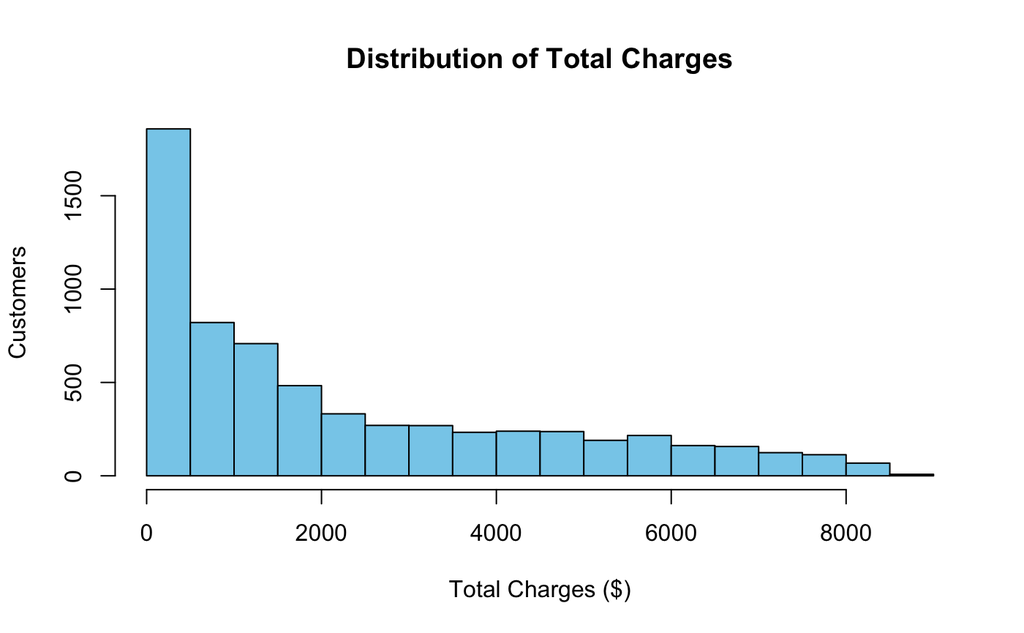

```r
hist(Model_Building_Data$TotalCharges,
     breaks = 30,
     main = "Distribution of Total Charges",
     xlab = "Total Charges ($)",
     ylab = "Customers",
     col = "skyblue")
```

*TotalCharges* is right skewed, so we can use median in order to update missing records.

```r
Model_Building_Data$TotalCharges[is.na(Model_Building_Data$TotalCharges)] <- median(Model_Building_Data$TotalCharges, na.rm = TRUE)
```

Now cross check the whether missing values are handled or not

```r
sapply(Model_Building_Data, function(x) sum(is.na(x)))
```

```
          Gender    SeniorCitizen          Partner       Dependents           Tenure     PhoneService
               0                0                0                0                0                0
   MultipleLines  InternetService   OnlineSecurity DeviceProtection  StreamingMovies         Contract
               0                0                0                0                0                0
PaperlessBilling    PaymentMethod   MonthlyCharges     TotalCharges           Status
               0                0                0                0                0
```

## 1.2 Exploratory Data Analysis

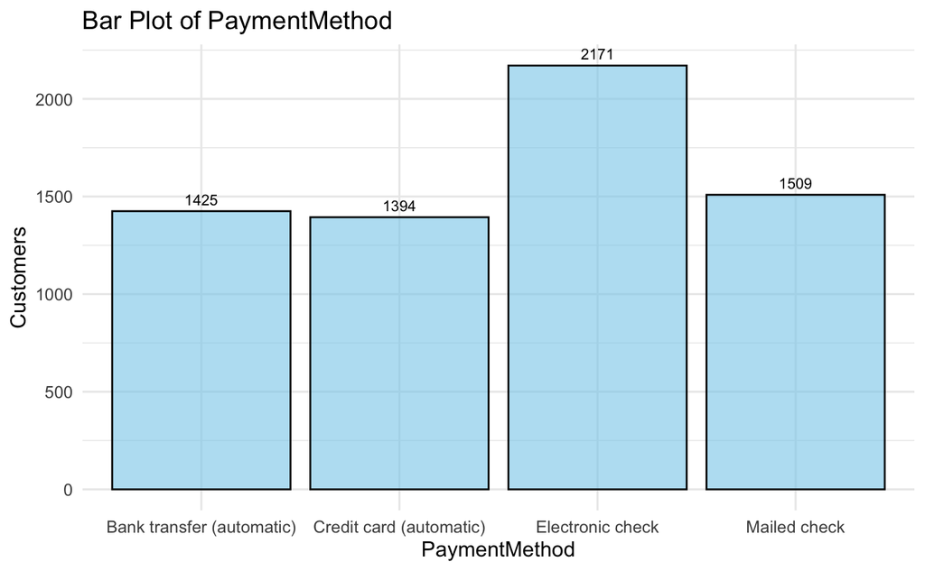

```r
ggplot(Model_Building_Data, aes(x = PaymentMethod)) +
  geom_bar(fill = "skyblue", color="black", alpha = 0.6) +
  geom_text(stat = "count", aes(label = after_stat(count)), vjust = -0.6, size = 3) +
  theme_minimal(base_size = 12) +
  labs(title = "Bar Plot of PaymentMethod", x = "PaymentMethod", y = "Customers")
```

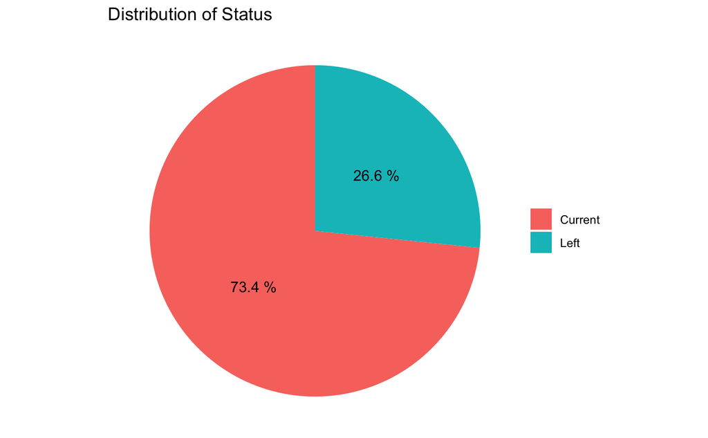

```r
status_counts <- table(Model_Building_Data$Status)
status_df <- as.data.frame(status_counts)
status_df$percentage <- round(100 * status_df$Freq / sum(status_df$Freq), 1)
ggplot(status_df, aes(x = "", y = Freq, fill = Var1)) +
  geom_bar(stat = "identity", width = 1) +
  coord_polar(theta = "y") +
  labs(title = "Distribution of Status") +
  theme_void() +
  theme(legend.title = element_blank()) +
  geom_text(aes(label = paste(percentage, "%")), position = position_stack(vjust = 0.5))
```

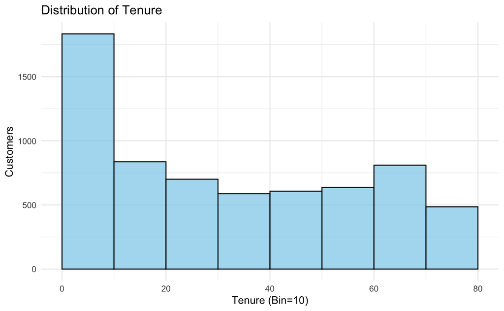

```r
ggplot(Model_Building_Data, aes(x = Tenure)) +
  geom_histogram(binwidth = 10, boundary = 0, fill = "skyblue", color = "black", alpha = 0.7) +
  labs(title = "Distribution of Tenure", x = "Tenure (Bin=10)", y = "Customers") +
  theme_minimal()
```

### Correlation

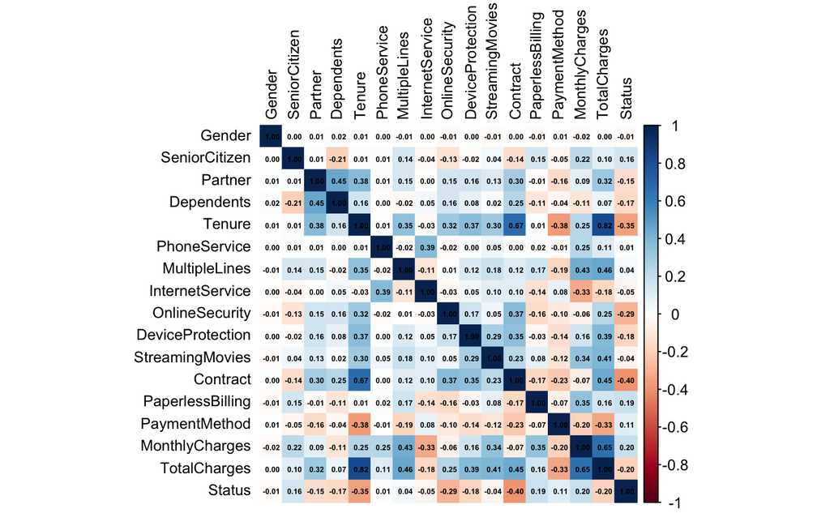

```r
data_numeric <- Model_Building_Data %>%
  mutate(across(where(is.factor), as.numeric))
cor_matrix <- cor(data_numeric, use = "complete.obs")

# Displaying correlation after rounding
#print(round(cor_matrix, 2))
corrplot(cor_matrix, method = "color",
         tl.col = "black",
         tl.cex = 0.8,
         addCoef.col = "black",
         number.cex = 0.4,
         number.font = 2,
         number.digits = 2)
```

### Training and Testing Dataset Preparation

We are dividing the entire dataset into 80% for training and 20% for testing.